# autism

mcdevitt

03 avr 2017

### Homework 11 - Problem Set 2 - Autism Prevalence

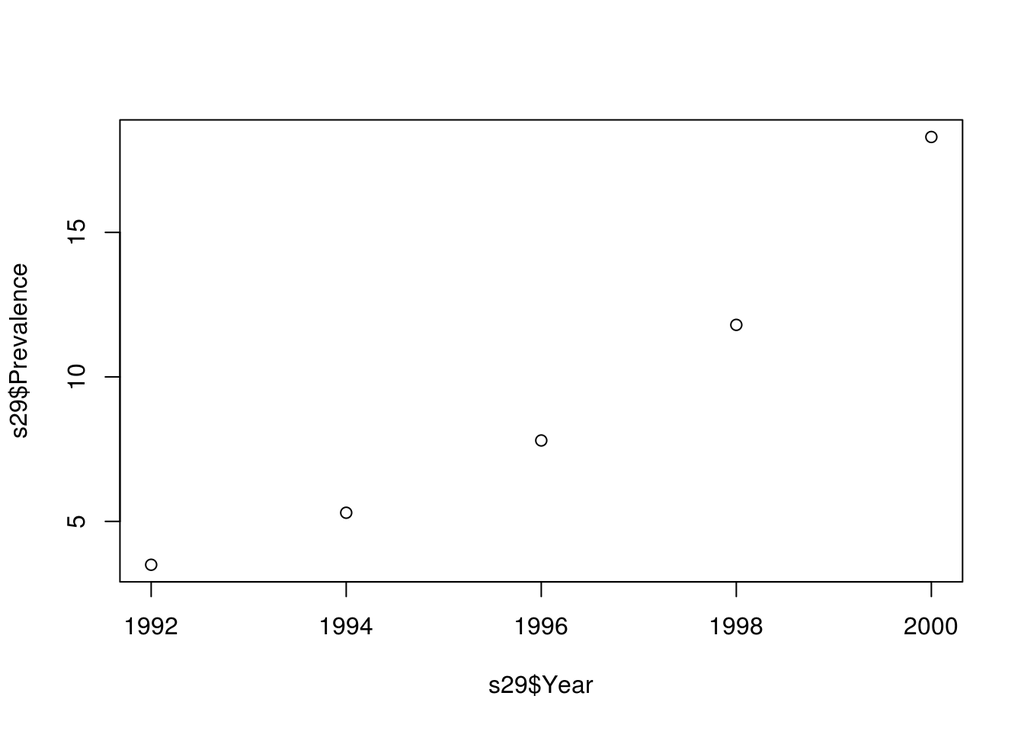

```r
home_dir <- "~/_smu/_src/autism/"
setwd(home_dir)
data_dir <- "./data"
setwd(data_dir)

s29 <- read.csv("ex0829.csv", stringsAsFactors = FALSE)

setwd(home_dir)

plot(s29$Prevalence ~ s29$Year)
```

```r
# ... define data set to analyze

s29$x2 <- (s29$Year - 1992) * (s29$Year - 1992)

df_xy <- data.frame(s29$Year, s29$Prevalence, s29$x2)

names(df_xy) <- c("xxx", "yyy", "x2")

str(df_xy)
```

```
## 'data.frame':    5 obs. of  3 variables:
##  $ xxx: int  1992 1994 1996 1998 2000
##  $ yyy: num  3.5 5.3 7.8 11.8 18.3
##  $ x2 : num  0 4 16 36 64
```

#### **scatter plot of the data shows general trend to be parabolic. Expect that linear fit is not appropriate for this data set. Have expectation that model in X^2 is likely a better fit. In any case, run the basic linear model on the raw data set to evaluate the results.**

=-=-=-=-=-=-=-=-=-=-=-=-=-=-=-=-=-=-=-=-=-=-=-=-=-=-=-=-=-=-=-=-=-=-=-=–=-=-=-  
### **i. A Scatterplot with confidence intervals of the regression line and prediction intervals of the regression line.**  
=-=-=-=-=-=-=-=-=-=-=-=-=-=-=-=-=-=-=-=-=-=-=-=-=-=-=-=-=-=-=-=-=-=-=-=–=-=-=-

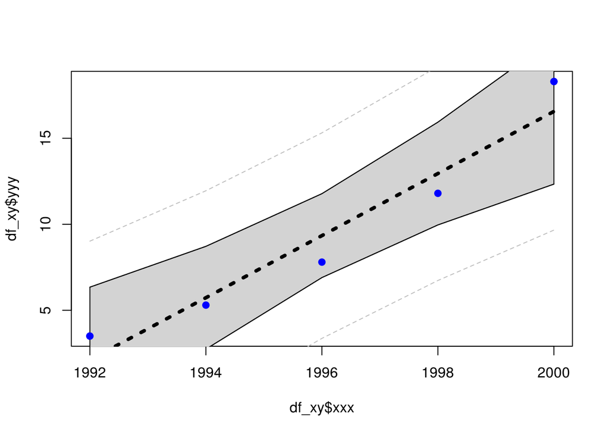

=-=-=-=-=-=-=-=-=-=-=-=-=-=-=-=-=-=-=-=-=-=-=-=-=-=-=-=-=-=-=-=-=-=-=-=–=-=-=-  
**ii. A table showing the t-statistics and pvalues for the significance of the regression parameters: .**  
=-=-=-=-=-=-=-=-=-=-=-=-=-=-=-=-=-=-=-=-=-=-=-=-=-=-=-=-=-=-=-=-=-=-=-=–=-=-=-

```
##
## Call:
## lm(formula = yyy ~ xxx, data = df_xy)
##
## Residuals:
##     1     2     3     4     5
##  1.38 -0.43 -1.54 -1.15  1.74
##
## Coefficients:
##              Estimate Std. Error t value Pr(>|t|)
## (Intercept) -3593.440    540.858  -6.644  0.00695 **
## xxx             1.805      0.271   6.661  0.00690 **
## ---
## Signif. codes:  0 '***' 0.001 '**' 0.01 '*' 0.05 '.' 0.1 ' ' 1
##
## Residual standard error: 1.714 on 3 degrees of freedom
## Multiple R-squared:  0.9367, Adjusted R-squared:  0.9156
## F-statistic: 44.37 on 1 and 3 DF,  p-value: 0.006897
```

=-=-=-=-=-=-=-=-=-=-=-=-=-=-=-=-=-=-=-=-=-=-=-=-=-=-=-=-=-=-=-=-=-=-=-=–=-=-=-  
### **iv. The regression equation.**  
=-=-=-=-=-=-=-=-=-=-=-=-=-=-=-=-=-=-=-=-=-=-=-=-=-=-=-=-=-=-=-=-=-=-=-=–=-=-=-

The Regression equation : * yyy = 1.805 * xxx + -3593.44

=-=-=-=-=-=-=-=-=-=-=-=-=-=-=-=-=-=-=-=-=-=-=-=-=-=-=-=-=-=-=-=-=-=-=-=–=-=-=-  
**x. A scatterplot of residuals.**  
=-=-=-=-=-=-=-=-=-=-=-=-=-=-=-=-=-=-=-=-=-=-=-=-=-=-=-=-=-=-=-=-=-=-=-=–=-=-=-

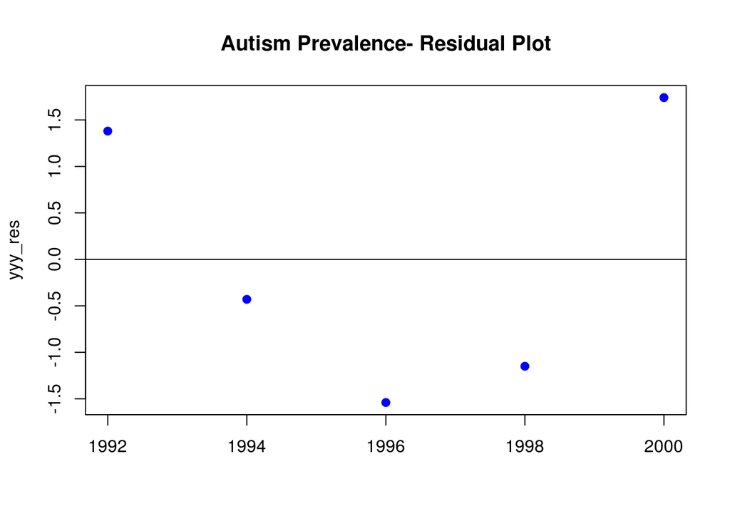

### –> As expected, the plot of residuals vs predicted values shows a non-random distribution. This demonstrates that the basic assumption of linearity for the model is not supported by the data set. Need to evaluate if data transformation model can provide a more appropriate fit for this data set. Since the Autism Prevalence rate visually appears to vary at the square of the year increase, a model based on (Year - 1992)^2 will be fit, using the base year (1992) as a reference year for the rest of the study period.

=-=-=-=-=-=-=-=-=-=-=-=-=-=-=-=-=-=-=-=-=-=-=-=-=-=-=-=-=-=-=-=-=-=-=-=–=-=-=-

#### b. Second Model —- Autism = b0 + b1 * (Year-1992)^2

=-=-=-=-=-=-=-=-=-=-=-=-=-=-=-=-=-=-=-=-=-=-=-=-=-=-=-=-=-=-=-=-=-=-=-=–=-=-=-  
=-=-=-=-=-=-=-=-=-=-=-=-=-=-=-=-=-=-=-=-=-=-=-=-=-=-=-=-=-=-=-=-=-=-=-=–=-=-=-

### **i. A Scatterplot with confidence intervals of the regression line and prediction intervals of the regression line.**

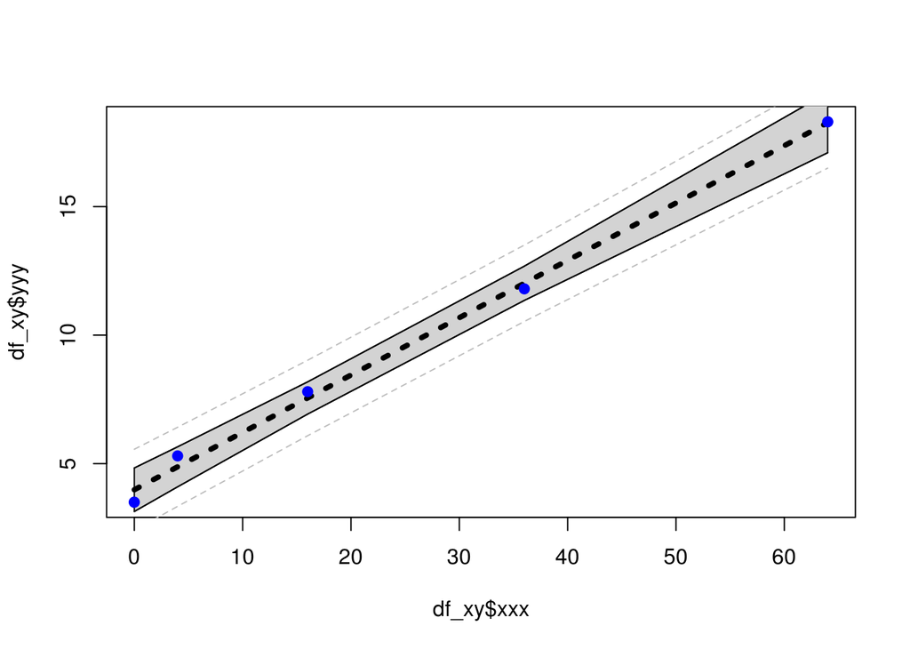

```
##
## Call:
## lm(formula = yyy ~ xxx, data = df_xy)
##
## Residuals:
##        1        2        3        4        5
## -0.48483  0.42264  0.24506 -0.21759  0.03471
##
## Coefficients:
##             Estimate Std. Error t value Pr(>|t|)
## (Intercept) 3.984828   0.266156   14.97 0.000647 ***
## xxx         0.223132   0.007908   28.22 9.77e-05 ***
## ---
## Signif. codes:  0 '***' 0.001 '**' 0.01 '*' 0.05 '.' 0.1 ' ' 1
##
## Residual standard error: 0.4172 on 3 degrees of freedom
## Multiple R-squared:  0.9962, Adjusted R-squared:  0.995
## F-statistic: 796.2 on 1 and 3 DF,  p-value: 9.772e-05
```

=-=-=-=-=-=-=-=-=-=-=-=-=-=-=-=-=-=-=-=-=-=-=-=-=-=-=-=-=-=-=-=-=-=-=-=–=-=-=-  
### **iii. Using the data in ii show all 6 steps of each hypothesis test.**  
=-=-=-=-=-=-=-=-=-=-=-=-=-=-=-=-=-=-=-=-=-=-=-=-=-=-=-=-=-=-=-=-=-=-=-=–=-=-=-

##### **Six-Step Hypothesis Test - Slope**

1: Ho : b1 = 0; Ha ; b1 != 0

2 : Critical Value : t(0.975, df = **3**) = +/- **3.1824463**

3 : t = 28.2164714

4 : p_value = 9.77242610^{-5} < 0.05 ?

5: Reject Ho

6 : There is sufficient evidence to suggest at the alpha = 0.05 level of significance (p-value = 9.77242610^{-5}) that the slope of the regression line that estimates the increase in Autism Prevalence as a function of (Year-1992)^2 is not equal to zero. A 95% confidence interval for the slope is ( 0.198, 0.248), which is an interval that does not contain the value zero

##### **Six-Step Hypothesis Test - Intercept**

1 : Ho : b0 = 0; Ha ; b0 != 0

2 : Critical Value : t(0.975, df = **3**) = +/- **3.1824463**

3 : t = 14.9717788

4 : p_value = 6.467243910^{-4} < 0.05 ?

5: Reject Ho

6 : There is sufficient evidence to suggest at the alpha = 0.05 level of significance (p-value = 6.467243910^{-4}) that the intercept of the regression line that estimates the increase in Autism Prevalence as a function of (Year-1992)^2 is not equal to zero. A 95% confidence interval for the slope is ( 3.138, 4.832), which is an interval that does not contain the value zero

=-=-=-=-=-=-=-=-=-=-=-=-=-=-=-=-=-=-=-=-=-=-=-=-=-=-=-=-=-=-=-=-=-=-=-=–=-=-=-  
**iv. The regression equation.**

### The Regression equation :

#### Autism Prevalence = 0.2231322 * (Year - 1992)^2 + 3.9848276

=-=-=-=-=-=-=-=-=-=-=-=-=-=-=-=-=-=-=-=-=-=-=-=-=-=-=-=-=-=-=-=-=-=-=-=–=-=-=-  
### **v. Interpretation of the slope and intercept in the model (regression equation.)**  
=-=-=-=-=-=-=-=-=-=-=-=-=-=-=-=-=-=-=-=-=-=-=-=-=-=-=-=-=-=-=-=-=-=-=-=–=-=-=-

#### **The intercept in this case is simply the model (expected) level of Autism Prevalence in the Reference Year of 1992, (Year 0) for this model. In this case, the model’s value = 3.9848276**

=-=-=-=-=-=-=-=-=-=-=-=-=-=-=-=-=-=-=-=-=-=-=-=-=-=-=-=-=-=-=-=-=-=-=-=–=-=-=-  
**x. A scatterplot of residuals.**

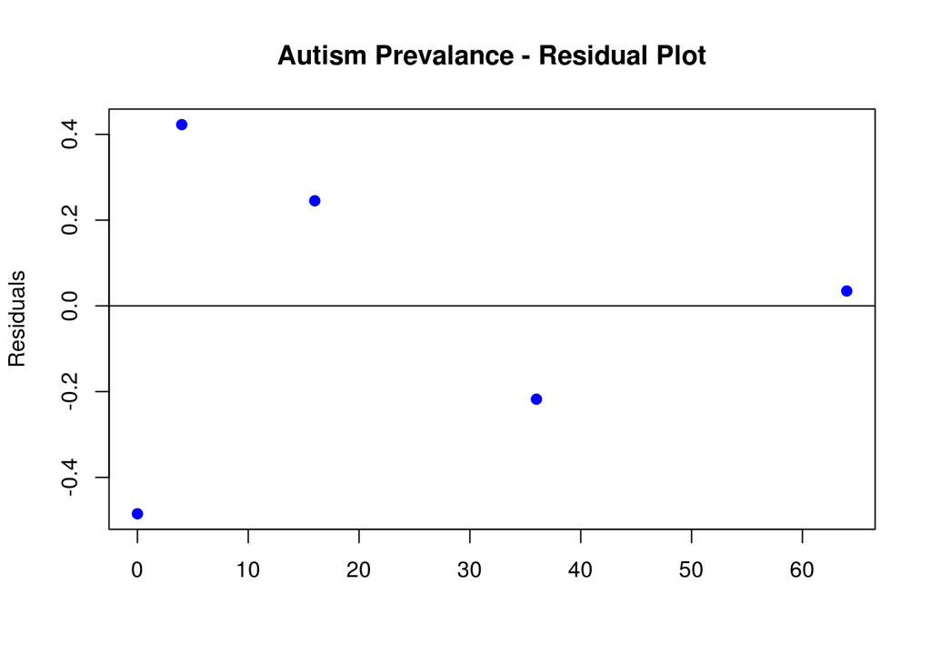

=-=-=-=-=-=-=-=-=-=-=-=-=-=-=-=-=-=-=-=-=-=-=-=-=-=-=-=-=-=-=-=-=-=-=-=–=-=-=-  
### **xi. A histogram of residuals with normal distribution superimposed.**  
=-=-=-=-=-=-=-=-=-=-=-=-=-=-=-=-=-=-=-=-=-=-=-=-=-=-=-=-=-=-=-=-=-=-=-=–=-=-=-

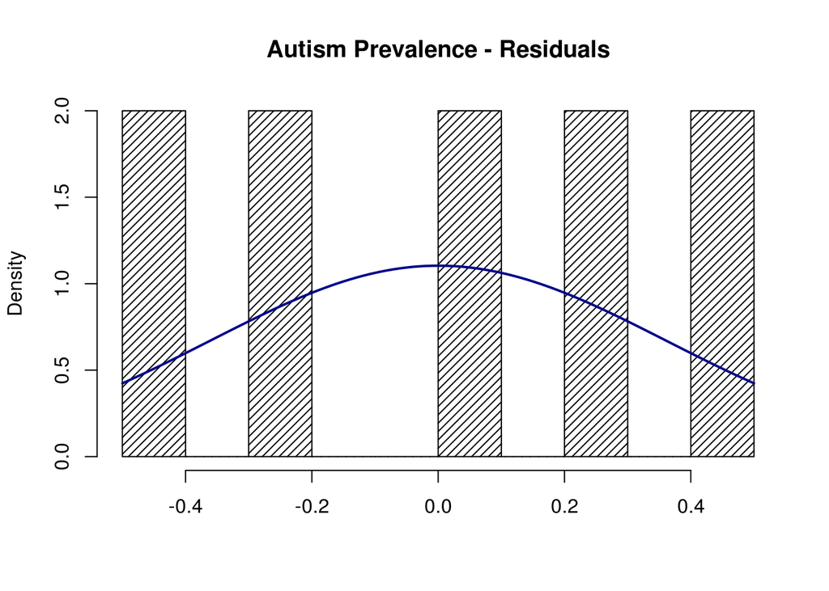

=-=-=-=-=-=-=-=-=-=-=-=-=-=-=-=-=-=-=-=-=-=-=-=-=-=-=-=-=-=-=-=-=-=-=-=–=-=-=-  
### **xii. Provide a measure of the amount of variation in the response that is accounted for by the explanatory variable. Interpret this measure clearly indicating the units of the response and the explanatory variables.**  
=-=-=-=-=-=-=-=-=-=-=-=-=-=-=-=-=-=-=-=-=-=-=-=-=-=-=-=-=-=-=-=-=-=-=-=–=-=-=-

```r
r2 <- summary.lm(fit_all, r.squared=TRUE)$r.squared
r2_format <- sprintf("%8.2f %%", r2*100)
non_r2_format <- sprintf("%8.2f %%", (1.0 - r2)*100)
```

#### R-squared value for model = 0.9962461

#### Therefore, 99.62 % of the variation observed in the dependent variable (Autism Prevalence) is explained by the increasing yearly count (with 1992 as the reference year) independent variable, leaving only 0.38 % variation that is available to be explained by any remaining contributory factors.

=-=-=-=-=-=-=-=-=-=-=-=-=-=-=-=-=-=-=-=-=-=-=-=-=-=-=-=-=-=-=-=-=-=-=-=–=-=-=-  
end-of-document  
=-=-=-=-=-=-=-=-=-=-=-=-=-=-=-=-=-=-=-=-=-=-=-=-=-=-=-=-=-=-=-=-=-=-=-=–=-=-=-